# Comparison of human and LLM humor appreciation

Drew Walker, Sean Trott, Seana Coulson

September 7, 2023

# Load data

## LLM data

### Load classification task

```r
## setwd("/Users/seantrott/Dropbox/UCSD/Research/NLMs/humor_llms/src/analysis")
df_class = read_csv("../../data/processed/llm_classification.csv")
nrow(df_class)
```

```
## [1] 400
```

```r
head(df_class)
```

```
## # A tibble: 6 × 10
##   model       sente…¹ answer shots condi…² correct yes_lp  no_lp lp_ra…³ is_joke
##   <chr>       <chr>   <chr>  <dbl> <chr>   <chr>    <dbl>  <dbl>   <dbl> <lgl>
## 1 text-davin… A comm… Commi…     0 J       no       -1.74 -1.06   -0.680 TRUE
## 2 text-davin… A comm… Commi…     0 S       yes      -7.38 -0.278  -7.10  FALSE
## 3 text-davin… A devi… The c…     0 S       yes      -3.01 -0.436  -2.57  FALSE
## 4 text-davin… A devi… Peopl…     0 J       yes      -3.02 -0.359  -2.66  TRUE
## 5 text-davin… A good… Carro…     0 E       yes     -10.2  -0.347  -9.81  FALSE
## 6 text-davin… A good… An ex…     0 J       yes      -4.76 -0.235  -4.52  TRUE
## # … with abbreviated variable names ¹sentence, ²condition, ³lp_ratio
```

### Load appreciation task

```r
## setwd("/Users/seantrott/Dropbox/UCSD/Research/NLMs/humor_llms/src/analysis")
df_app = read_csv("../../data/processed/llm_appreciation.csv")
nrow(df_app)
```

```
## [1] 400
```

```r
head(df_app)
```

```
## # A tibble: 6 × 8
##   model            sentence       answer condi…¹ best_…² best_…³ entropy is_joke
##   <chr>            <chr>          <chr>  <chr>     <dbl>   <dbl>   <dbl> <lgl>
## 1 text-davinci-002 A committee k… Commi… J             3  -0.616  0.695  TRUE
## 2 text-davinci-002 A committee k… Commi… S             1  -0.649  0.670  FALSE
## 3 text-davinci-002 A device for … The c… S             3  -0.614  0.641  FALSE
## 4 text-davinci-002 A device for … Peopl… J             3  -0.393  0.705  TRUE
## 5 text-davinci-002 A good source… Carro… E             1  -0.101  0.0984 FALSE
## 6 text-davinci-002 A good way to… An ex… J             1  -0.150  0.285  TRUE
## # … with abbreviated variable names ¹condition, ²best_response,
## #   ³best_response_lp
```

### Load surprisals

```r
## setwd("/Users/seantrott/Dropbox/UCSD/Research/NLMs/humor_llms/src/analysis")
df_surprisals = read_csv("../../data/processed/results_gpt.csv")
df_surprisals_td02 = df_surprisals %>%
  filter(model == "text-davinci-002")

### clean up
df_surprisals_td02 = df_surprisals_td02 %>%
  mutate(Sentence = sentence) %>%
  mutate(StimType = case_when(
    condition == "J" ~ "joke",
    condition == "E" ~ "expected",
    condition == "S" ~ "straight"
  )) %>%
  select(Sentence, StimType, log_prob, surprisal, num_tokens)
```

## Human data

```r
# setwd("/Users/seantrott/Dropbox/UCSD/Research/NLMs/humor_llms/src/analysis")
df_cleaned = read_csv("../../data/processed/human_data_appreciation/JokeFunniness_data_153Subs.csv")
nrow(df_cleaned)
```

```
## [1] 18360
```

```r
head(df_cleaned)
```

```
## # A tibble: 6 × 14
##   Event.Index Particip…¹ Trial…² Respo…³ Respo…⁴ React…⁵ Sente…⁶ Sprea…⁷ Sprea…⁸
##         <dbl>      <dbl>   <dbl>   <dbl>   <dbl>   <dbl> <chr>     <dbl>   <dbl>
## 1         213    9134620      71       0       1   4142  A good…    3.90       1
## 2         132    9135151      44       0       1   8590. A good…    3.90       1
## 3         279    9135260      93       0       1   2319. A good…    3.90       1
## 4          24    9135533       8       0       1   5644. A good…    3.90       1
## 5          36    9135632      12       0       1   6629. A good…    3.90       1
## 6         351    9141554     117       0       1   2973. A good…    3.90       1
## # … with 5 more variables: Spreadsheet..Last_Event_Code <dbl>, StimType <chr>,
## #   Spreadsheet..YokedSet <chr>, Is_Joke <dbl>, IsJokeResponseCorrect <dbl>,
## #   and abbreviated variable names ¹ParticipantID, ²Trial.Number,
## #   ³ResponseJoke, ⁴ResponseFunny, ⁵Reaction.Time, ⁶Sentence,
## #   ⁷Spreadsheet..Surprisal, ⁸Spreadsheet..NumTokens
## # ℹ Use `colnames()` to see all variable names
```

```r
length(unique(df_cleaned$ParticipantID))
```

```
## [1] 153
```

### Merge with LLM surprisal

```r
df_merged_surprisal = df_cleaned %>%
  left_join(df_surprisals_td02)
nrow(df_merged_surprisal)
```

```
## [1] 18360
```

### Exclusions

Exclusion criteria have already been applied.

# Analysis of human data

First, we conduct an analysis of the human data.

## Classification: `ResponseJoke ~ Is_Joke`

First, we ask whether humans correctly identify jokes as jokes, and vice versa.

```r
mod_full = glmer(data = df_cleaned,
                 ResponseJoke ~ Is_Joke + (1 | ParticipantID) +
                   (1 | Sentence),
                 family = binomial())

mod_reduced = glmer(data = df_cleaned,
                 ResponseJoke ~  (1 | ParticipantID) +
                   (1 | Sentence),
                 family = binomial())

summary(mod_full)
```

```
## Generalized linear mixed model fit by maximum likelihood (Laplace
##   Approximation) [glmerMod]
##  Family: binomial  ( logit )
## Formula: ResponseJoke ~ Is_Joke + (1 | ParticipantID) + (1 | Sentence)
##    Data: df_cleaned
##
##      AIC      BIC   logLik deviance df.resid
##  13245.5  13276.8  -6618.8  13237.5    18356
##
## Scaled residuals:
##     Min      1Q  Median      3Q     Max
## -9.7472 -0.3264 -0.1300  0.3174 13.9293
##
## Random effects:
##  Groups        Name        Variance Std.Dev.
##  Sentence      (Intercept) 2.557    1.599
##  ParticipantID (Intercept) 1.031    1.016
## Number of obs: 18360, groups:  Sentence, 400; ParticipantID, 153
##
## Fixed effects:
##             Estimate Std. Error z value Pr(>|z|)
## (Intercept)  -2.3308     0.1382  -16.87   <2e-16 ***
## Is_Joke       3.9934     0.1745   22.88   <2e-16 ***
## ---
## Signif. codes:  0 '***' 0.001 '**' 0.01 '*' 0.05 '.' 0.1 ' ' 1
##
## Correlation of Fixed Effects:
##         (Intr)
## Is_Joke -0.520
```

```r
anova(mod_full, mod_reduced)
```

```
## Data: df_cleaned
## Models:
## mod_reduced: ResponseJoke ~ (1 | ParticipantID) + (1 | Sentence)
## mod_full: ResponseJoke ~ Is_Joke + (1 | ParticipantID) + (1 | Sentence)
##             npar   AIC   BIC  logLik deviance  Chisq Df Pr(>Chisq)
## mod_reduced    3 13589 13612 -6791.3    13583
## mod_full       4 13246 13277 -6618.8    13238 345.07  1  < 2.2e-16 ***
## ---
## Signif. codes:  0 '***' 0.001 '**' 0.01 '*' 0.05 '.' 0.1 ' ' 1
```

The answer is **yes**: in general people are very accurate.

```r
df_cleaned = df_cleaned %>%
  mutate(correct_isjoke = ResponseJoke == Is_Joke)

mean(df_cleaned$correct_isjoke)
```

```
## [1] 0.8138889
```

```r
df_cleaned %>%
  group_by(Is_Joke) %>%
  summarize(accuracy = mean(correct_isjoke))
```

```
## # A tibble: 2 × 2
##   Is_Joke accuracy
##     <dbl>    <dbl>
## 1       0    0.841
## 2       1    0.759
```

## Adding `Surprisal`

### `Response ~ Surprisal + Is_Joke`

Does surprisal of the final word influence responses, above and beyond `Is_Joke`? And vice versa?

```r
mod_full = glmer(data = df_merged_surprisal,
                 ResponseJoke ~ Is_Joke + surprisal + (1 | ParticipantID) +
                   (1 | Sentence),
                 family = binomial())

mod_isjoke = glmer(data = df_merged_surprisal,
                 ResponseJoke ~  Is_Joke + (1 | ParticipantID) +
                   (1 | Sentence),
                 family = binomial())

mod_surprisal = glmer(data = df_merged_surprisal,
                 ResponseJoke ~  surprisal + (1 | ParticipantID) +
                   (1 | Sentence),
                 family = binomial())

summary(mod_full)
```

```
## Generalized linear mixed model fit by maximum likelihood (Laplace
##   Approximation) [glmerMod]
##  Family: binomial  ( logit )
## Formula: ResponseJoke ~ Is_Joke + surprisal + (1 | ParticipantID) + (1 |
##     Sentence)
##    Data: df_merged_surprisal
##
##      AIC      BIC   logLik deviance df.resid
##  13166.2  13205.3  -6578.1  13156.2    18355
##
## Scaled residuals:
##      Min       1Q   Median       3Q      Max
## -10.1285  -0.3274  -0.1256   0.3181  14.6627
##
## Random effects:
##  Groups        Name        Variance Std.Dev.
##  Sentence      (Intercept) 2.039    1.428
##  ParticipantID (Intercept) 1.023    1.012
## Number of obs: 18360, groups:  Sentence, 400; ParticipantID, 153
##
## Fixed effects:
##             Estimate Std. Error z value Pr(>|z|)
## (Intercept) -3.23263    0.16438 -19.666   <2e-16 ***
## Is_Joke      3.22560    0.17456  18.479   <2e-16 ***
## surprisal    0.17511    0.01858   9.427   <2e-16 ***
## ---
## Signif. codes:  0 '***' 0.001 '**' 0.01 '*' 0.05 '.' 0.1 ' ' 1
##
## Correlation of Fixed Effects:
##           (Intr) Is_Jok
## Is_Joke   -0.103
## surprisal -0.612 -0.422
```

```r
anova(mod_full, mod_isjoke)
```

```
## Data: df_merged_surprisal
## Models:
## mod_isjoke: ResponseJoke ~ Is_Joke + (1 | ParticipantID) + (1 | Sentence)
## mod_full: ResponseJoke ~ Is_Joke + surprisal + (1 | ParticipantID) + (1 | Sentence)
##            npar   AIC   BIC  logLik deviance  Chisq Df Pr(>Chisq)
## mod_isjoke    4 13246 13277 -6618.8    13238
## mod_full      5 13166 13205 -6578.1    13156 81.388  1  < 2.2e-16 ***
## ---
## Signif. codes:  0 '***' 0.001 '**' 0.01 '*' 0.05 '.' 0.1 ' ' 1
```

```r
anova(mod_full, mod_surprisal)
```

```
## Data: df_merged_surprisal
## Models:
## mod_surprisal: ResponseJoke ~ surprisal + (1 | ParticipantID) + (1 | Sentence)
## mod_full: ResponseJoke ~ Is_Joke + surprisal + (1 | ParticipantID) + (1 | Sentence)
##               npar   AIC   BIC  logLik deviance  Chisq Df Pr(>Chisq)
## mod_surprisal    4 13414 13445 -6702.8    13406
## mod_full         5 13166 13205 -6578.1    13156 249.47  1  < 2.2e-16 ***
## ---
## Signif. codes:  0 '***' 0.001 '**' 0.01 '*' 0.05 '.' 0.1 ' ' 1
```

Again, the answer is **yes**: both variables *independently predict* classification of something as a joke.

### `Funniness ~ Is_Joke * Surprisal`

Now we ask: does the surprisal of the final word influence **funniness ratings**, above and beyond `Is_Joke`? And vice versa? And is there an interaction?

```r
mod_interaction = lmer(data = df_merged_surprisal,
                 ResponseFunny ~ Is_Joke * surprisal + (1 | ParticipantID) +
                   (1 | Sentence),
                 REML = FALSE)

mod_me = lmer(data = df_merged_surprisal,
                 ResponseFunny ~ Is_Joke + surprisal + (1 | ParticipantID) +
                   (1 | Sentence),
                 REML = FALSE)

mod_isjoke = lmer(data = df_merged_surprisal,
                 ResponseFunny ~  Is_Joke + (1 | ParticipantID) +
                   (1 | Sentence),
                 REML = FALSE)

mod_surprisal = lmer(data = df_merged_surprisal,
                 ResponseFunny ~  surprisal + (1 | ParticipantID) +
                   (1 | Sentence),
                 REML = FALSE)

summary(mod_interaction)
```

```
## Linear mixed model fit by maximum likelihood . t-tests use Satterthwaite's
##   method [lmerModLmerTest]
## Formula: ResponseFunny ~ Is_Joke * surprisal + (1 | ParticipantID) + (1 |
##     Sentence)
##    Data: df_merged_surprisal
##
##      AIC      BIC   logLik deviance df.resid
##  41228.1  41282.8 -20607.0  41214.1    18353
##
## Scaled residuals:
##     Min      1Q  Median      3Q     Max
## -3.8400 -0.5693 -0.1011  0.3679  5.5186
##
## Random effects:
##  Groups        Name        Variance Std.Dev.
##  Sentence      (Intercept) 0.08421  0.2902
##  ParticipantID (Intercept) 0.13948  0.3735
##  Residual                  0.51274  0.7161
## Number of obs: 18360, groups:  Sentence, 400; ParticipantID, 153
##
## Fixed effects:
##                     Estimate Std. Error         df t value Pr(>|t|)
## (Intercept)         1.142668   0.043547 421.990409  26.240  < 2e-16 ***
## Is_Joke             1.021730   0.069764 389.955652  14.645  < 2e-16 ***
## surprisal           0.030236   0.004818 376.536333   6.276 9.58e-10 ***
## Is_Joke:surprisal  -0.032524   0.007740 390.014878  -4.202 3.28e-05 ***
## ---
## Signif. codes:  0 '***' 0.001 '**' 0.01 '*' 0.05 '.' 0.1 ' ' 1
##
## Correlation of Fixed Effects:
##             (Intr) Is_Jok srprsl
## Is_Joke     -0.324
## surprisal   -0.556  0.347
## Is_Jk:srprs  0.347 -0.858 -0.623
```

```r
anova(mod_me, mod_interaction)
```

```
## Data: df_merged_surprisal
## Models:
## mod_me: ResponseFunny ~ Is_Joke + surprisal + (1 | ParticipantID) + (1 | Sentence)
## mod_interaction: ResponseFunny ~ Is_Joke * surprisal + (1 | ParticipantID) + (1 | Sentence)
##                 npar   AIC   BIC logLik deviance  Chisq Df Pr(>Chisq)
## mod_me             6 41243 41290 -20616    41231
## mod_interaction    7 41228 41283 -20607    41214 17.281  1  3.224e-05 ***
## ---
## Signif. codes:  0 '***' 0.001 '**' 0.01 '*' 0.05 '.' 0.1 ' ' 1
```

```r
anova(mod_me, mod_isjoke)
```

```
## Data: df_merged_surprisal
## Models:
## mod_isjoke: ResponseFunny ~ Is_Joke + (1 | ParticipantID) + (1 | Sentence)
## mod_me: ResponseFunny ~ Is_Joke + surprisal + (1 | ParticipantID) + (1 | Sentence)
##            npar   AIC   BIC logLik deviance  Chisq Df Pr(>Chisq)
## mod_isjoke    5 41262 41301 -20626    41252
## mod_me        6 41243 41290 -20616    41231 20.298  1  6.628e-06 ***
## ---
## Signif. codes:  0 '***' 0.001 '**' 0.01 '*' 0.05 '.' 0.1 ' ' 1
```

```r
anova(mod_me, mod_surprisal)
```

```
## Data: df_merged_surprisal
## Models:
## mod_surprisal: ResponseFunny ~ surprisal + (1 | ParticipantID) + (1 | Sentence)
## mod_me: ResponseFunny ~ Is_Joke + surprisal + (1 | ParticipantID) + (1 | Sentence)
##               npar   AIC   BIC logLik deviance  Chisq Df Pr(>Chisq)
## mod_surprisal    5 41538 41577 -20764    41528
## mod_me           6 41243 41290 -20616    41231 296.56  1  < 2.2e-16 ***
## ---
## Signif. codes:  0 '***' 0.001 '**' 0.01 '*' 0.05 '.' 0.1 ' ' 1
```

Once again, the answer is **yes**.

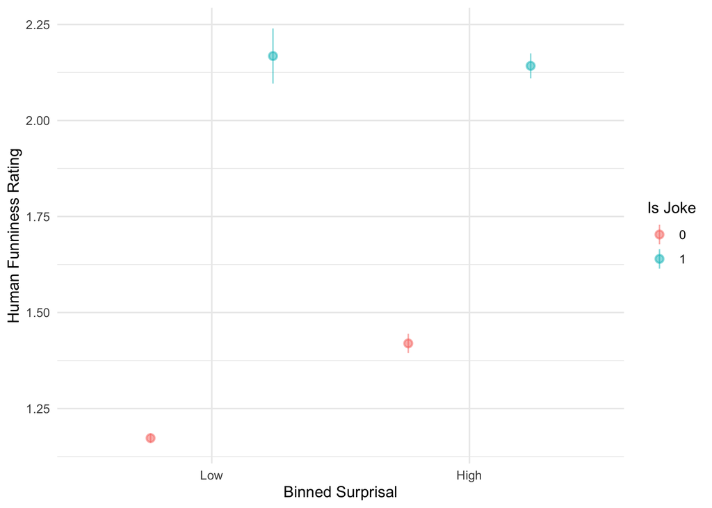

```r
df_merged_surprisal %>%
  mutate(surprisal_binned = ifelse(ntile(surprisal, 2) == 1, "Low", "High")) %>%
  mutate(surprisal_binned = fct_relevel(surprisal_binned, "Low")) %>%
  ggplot(aes(x = surprisal_binned,
             y = ResponseFunny,
             color = factor(Is_Joke))) +
  stat_summary (fun = function(x){mean(x)},
                fun.min = function(x){mean(x) - 2*sd(x)/sqrt(length(x))},
                fun.max = function(x){mean(x) + 2*sd(x)/sqrt(length(x))},
                geom= 'pointrange',
                position=position_dodge(width=0.95),
                size = .5, alpha = .5) +
  theme_minimal() +
  labs(x = "Binned Surprisal",
       y = "Human Funniness Rating",
       color = "Is Joke")
```

# Comparison of human and LLM performance

## Approach 1

In this first analysis, we directly compare LLM and human accuracy.

### Merging data

#### Classification data

```r
df_class_cleaned_direct = df_class %>%
  mutate(Sentence = sentence) %>%
  mutate(StimType = case_when(
    condition == "J" ~ "joke",
    condition == "E" ~ "expected",
    condition == "S" ~ "straight"
  )) %>%
  mutate(ResponseJoke = case_when(
    lp_ratio > 0 ~ 1,
    lp_ratio <= 0 ~ 0
  )) %>%
  mutate(Is_Joke = case_when(
    is_joke == TRUE ~ 1,
    is_joke == FALSE ~ 0
  )) %>%
  mutate(IsJokeResponseCorrect = Is_Joke == ResponseJoke) %>%
  select(Sentence, StimType, Is_Joke, ResponseJoke, IsJokeResponseCorrect, lp_ratio) %>%
  mutate(Source = "text-davinci-002") %>%
  inner_join(df_surprisals_td02)
mean(df_class_cleaned_direct$ResponseJoke)
```

```
## [1] 0.105
```

```r
mean(df_class_cleaned_direct$IsJokeResponseCorrect)
```

```
## [1] 0.675
```

```r
df_merged_class_stacked = df_merged_surprisal %>%
  # mutate(Sentence = paste(Sentence, ".", sep = "")) %>%
  mutate(Source = "Human") %>%
  bind_rows(df_class_cleaned_direct)

nrow(df_merged_class_stacked)
```

```
## [1] 18760
```

#### Appreciation data

```r
df_app_cleaned_direct = df_app %>%
  mutate(Sentence = sentence) %>%
  mutate(StimType = case_when(
    condition == "J" ~ "joke",
    condition == "E" ~ "expected",
    condition == "S" ~ "straight"
  )) %>%
  mutate(ResponseFunny = best_response) %>%
  mutate(Is_Joke = case_when(
    is_joke == TRUE ~ 1,
    is_joke == FALSE ~ 0
  )) %>%
  select(Sentence, StimType, Is_Joke, ResponseFunny) %>%
  mutate(Source = "text-davinci-002") %>%
  inner_join(df_surprisals_td02)
df_merged_app_stacked = df_merged_surprisal %>%
  # mutate(Sentence = paste(Sentence, ".", sep = "")) %>%
  mutate(Source = "Human") %>%
  bind_rows(df_app_cleaned_direct)

nrow(df_merged_app_stacked)
```

```
## [1] 18760
```

### Humans vs. LLMs: humor detection

#### `Correct Response ~ Source`

Both humans and LLMs show sensitivity to whether something is a joke, but td-002 is biased towards assigning lower probability towards something being a joke in general. Thus, overall, humans are considerably more accurate (especially for jokes).

```r
mod_just_source = glmer(data = df_merged_class_stacked,
                 IsJokeResponseCorrect ~ Source +
                   (1 | Sentence),
                 family = binomial(),
                 control=glmerControl(optimizer="bobyqa"))

mod_no_source = glmer(data = df_merged_class_stacked,
                 IsJokeResponseCorrect ~ # Source +
                   (1 | Sentence),
                 family = binomial(),
                 control=glmerControl(optimizer="bobyqa"))

summary(mod_just_source)
```

```
## Generalized linear mixed model fit by maximum likelihood (Laplace
##   Approximation) [glmerMod]
##  Family: binomial  ( logit )
## Formula: IsJokeResponseCorrect ~ Source + (1 | Sentence)
##    Data: df_merged_class_stacked
## Control: glmerControl(optimizer = "bobyqa")
##
##      AIC      BIC   logLik deviance df.resid
##  14981.6  15005.1  -7487.8  14975.6    18757
##
## Scaled residuals:
##     Min      1Q  Median      3Q     Max
## -6.3841  0.1264  0.2664  0.4450  2.8622
##
## Random effects:
##  Groups   Name        Variance Std.Dev.
##  Sentence (Intercept) 1.993    1.412
## Number of obs: 18760, groups:  Sentence, 400
##
## Fixed effects:
##                        Estimate Std. Error z value Pr(>|z|)
## (Intercept)             1.78250    0.07549  23.613  < 2e-16 ***
## Sourcetext-davinci-002 -0.76239    0.12379  -6.158 7.35e-10 ***
## ---
## Signif. codes:  0 '***' 0.001 '**' 0.01 '*' 0.05 '.' 0.1 ' ' 1
##
## Correlation of Fixed Effects:
##             (Intr)
## Srctxt--002 -0.054
```

```r
anova(mod_just_source, mod_no_source)
```

```
## Data: df_merged_class_stacked
## Models:
## mod_no_source: IsJokeResponseCorrect ~ (1 | Sentence)
## mod_just_source: IsJokeResponseCorrect ~ Source + (1 | Sentence)
##                 npar   AIC   BIC  logLik deviance  Chisq Df Pr(>Chisq)
## mod_no_source      2 15014 15030 -7505.2    15010
## mod_just_source    3 14982 15005 -7487.8    14976 34.842  1  3.576e-09 ***
## ---
## Signif. codes:  0 '***' 0.001 '**' 0.01 '*' 0.05 '.' 0.1 ' ' 1
```

We can describe and visualize this in a few ways.

First, the overall descriptive statistics:

```r
df_merged_class_stacked %>%
  group_by(Source) %>%
  summarise(accuracy = mean(IsJokeResponseCorrect))
```

```
## # A tibble: 2 × 2
##   Source           accuracy
##   <chr>               <dbl>
## 1 Human               0.814
## 2 text-davinci-002    0.675
```

```r
df_merged_class_stacked %>%
  group_by(Source, Is_Joke) %>%
  summarise(accuracy = mean(IsJokeResponseCorrect))
```

```
## # A tibble: 4 × 3
## # Groups:   Source [2]
##   Source           Is_Joke accuracy
##   <chr>              <dbl>    <dbl>
## 1 Human                  0    0.841
## 2 Human                  1    0.759
## 3 text-davinci-002       0    0.975
## 4 text-davinci-002       1    0.225
```

Then, comparing LLM accuracy to human distribution of accuracy:

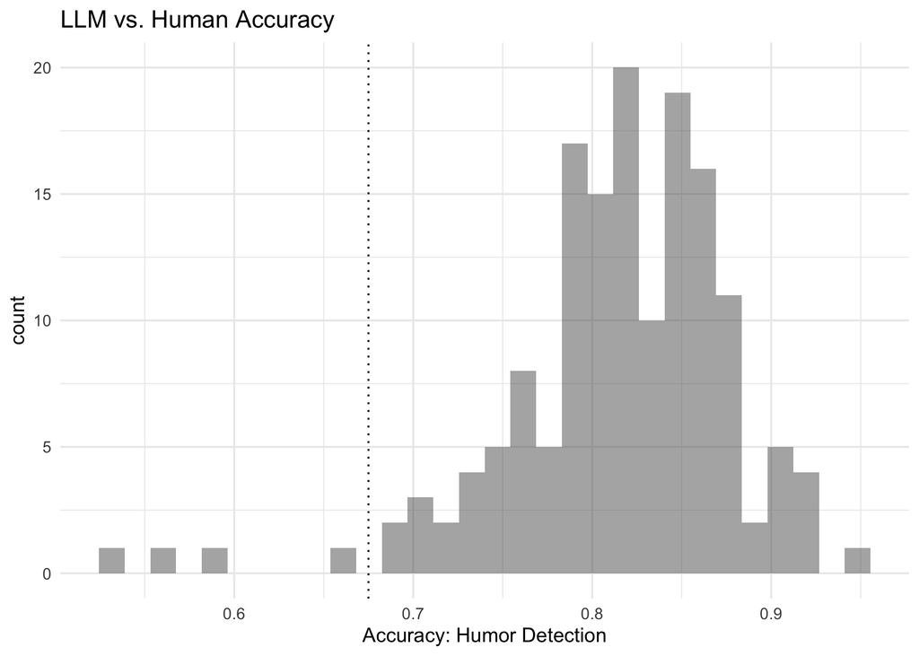

```r
df_by_subj = df_merged_surprisal %>%
  group_by(ParticipantID) %>%
  summarise(accuracy = mean(IsJokeResponseCorrect))

llm_accuracy = mean(df_class_cleaned_direct$IsJokeResponseCorrect)

df_by_subj %>%
  ggplot(aes(x = accuracy)) +
  geom_histogram(alpha = .5) +
  geom_vline(xintercept = llm_accuracy, linetype = "dotted") +
  theme_minimal() +
  labs(x = "Accuracy: Humor Detection",
       title = "LLM vs. Human Accuracy")
```

Comparing to humans in a plot:

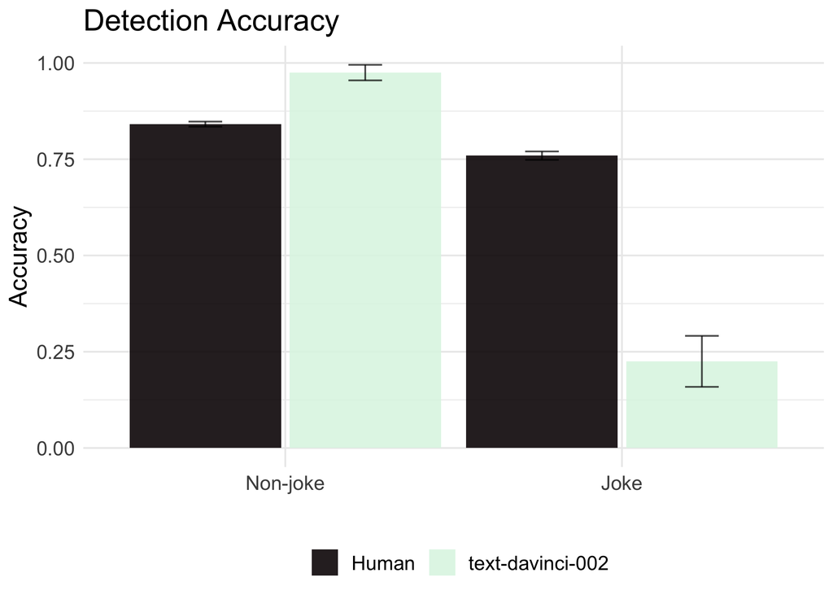

```r
df_merged_class_stacked = df_merged_class_stacked %>%
  mutate(is_joke = case_when(
    Is_Joke == 1 ~ "Joke",
    Is_Joke == 0 ~ "Non-joke"
  ))
df_merged_class_stacked$is_joke = factor(df_merged_class_stacked$is_joke, levels=c("Non-joke", "Joke"))

df_merged_class_stacked %>%
  ggplot(aes(x = is_joke,
             y = IsJokeResponseCorrect,
             fill = Source)) +
  stat_summary (fun = function(x){mean(x)},
                geom = "col",
                position=position_dodge(width=0.95),
                size = .5, alpha = .9) +
  stat_summary (fun = function(x){mean(x)},
                geom = "errorbar",
                fun.min = function(x){mean(x) - 2*sd(x)/sqrt(length(x))},
                fun.max = function(x){mean(x) + 2*sd(x)/sqrt(length(x))},
                position=position_dodge(width=0.95),
                width = .2, alpha = .7) +
  labs(x = "",
       y = "Accuracy",
       fill = "",
       title = "Detection Accuracy") +
  # scale_y_continuous(limits = c(0, 1)) +
  # geom_hline(yintercept = .5, linetype = "dotted") +
    theme_minimal() +
  theme(text = element_text(size = 15),
        legend.position="bottom") +
   scale_fill_viridis(option = "mako", discrete=TRUE)
```

#### `ResponseJoke ~ Source * surprisal`

Are human or LLM responses more influenced by final-word surprisal? Somewhat surprisingly, it appears the positive effect of `surprisal` is *mildly but significantly attenuated* for LLMs. That is, the model with interactions detects the following effects:

- LLMs are less likely to classify things as jokes.
- Sentence-final `surprisal` is positively correlated with `p(joke)`.
- But for LLMs, sentence-final `surprisal` is less predictive of `p(joke)`.

```r
mod_interaction = glmer(data = df_merged_class_stacked,
                 ResponseJoke ~ Source * surprisal +
                   (1 | Sentence),
                 family = binomial(),
                 control=glmerControl(optimizer="bobyqa"))

mod_just_fe = glmer(data = df_merged_class_stacked,
                 ResponseJoke ~ Source + surprisal +
                   (1 | Sentence),
                 family = binomial(),
                 control=glmerControl(optimizer="bobyqa"))

summary(mod_interaction)
```

```
## Generalized linear mixed model fit by maximum likelihood (Laplace
##   Approximation) [glmerMod]
##  Family: binomial  ( logit )
## Formula: ResponseJoke ~ Source * surprisal + (1 | Sentence)
##    Data: df_merged_class_stacked
## Control: glmerControl(optimizer = "bobyqa")
##
##      AIC      BIC   logLik deviance df.resid
##  14825.6  14864.8  -7407.8  14815.6    18755
##
## Scaled residuals:
##     Min      1Q  Median      3Q     Max
## -4.6311 -0.3872 -0.1388  0.3931 10.3470
##
## Random effects:
##  Groups   Name        Variance Std.Dev.
##  Sentence (Intercept) 3.261    1.806
## Number of obs: 18760, groups:  Sentence, 400
##
## Fixed effects:
##                                  Estimate Std. Error z value Pr(>|z|)
## (Intercept)                      -2.78047    0.17237 -16.131  < 2e-16 ***
## Sourcetext-davinci-002           -1.79836    0.43383  -4.145 3.39e-05 ***
## surprisal                         0.30468    0.02058  14.807  < 2e-16 ***
## Sourcetext-davinci-002:surprisal -0.12445    0.04717  -2.638  0.00834 **
## ---
## Signif. codes:  0 '***' 0.001 '**' 0.01 '*' 0.05 '.' 0.1 ' ' 1
##
## Correlation of Fixed Effects:
##             (Intr) Sr--002 srprsl
## Srctxt--002 -0.021
## surprisal   -0.837  0.019
## Srctx--002:  0.022 -0.896  -0.029
```

```r
anova(mod_interaction, mod_just_fe)
```

```
## Data: df_merged_class_stacked
## Models:
## mod_just_fe: ResponseJoke ~ Source + surprisal + (1 | Sentence)
## mod_interaction: ResponseJoke ~ Source * surprisal + (1 | Sentence)
##                 npar   AIC   BIC  logLik deviance  Chisq Df Pr(>Chisq)
## mod_just_fe        4 14831 14862 -7411.3    14823
## mod_interaction    5 14826 14865 -7407.8    14816 6.9922  1   0.008187 **
## ---
## Signif. codes:  0 '***' 0.001 '**' 0.01 '*' 0.05 '.' 0.1 ' ' 1
```

This point can be illustrated by *binning surprisal*, then plotting `p(joke)` for both humans and LLMs. We see that:

- For jokes, humans are unaffected by sentence-final surprisal.
- For non-jokes, humans are positively affected, i.e., `p(joke)` goes up.
- There is no significant difference in `p(joke)` for LLMs as a function of surprisal.

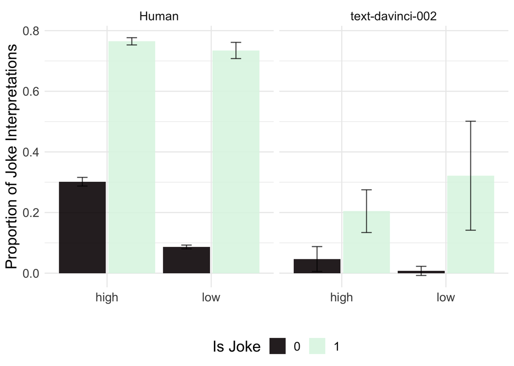

```r
df_merged_class_stacked %>%
  mutate(surprisal_binned = ifelse(ntile(surprisal, 2) == 1, "low", "high")) %>%
  ggplot(aes(x = surprisal_binned,
             y = ResponseJoke,
             fill = factor(Is_Joke))) +
  stat_summary (fun = function(x){mean(x)},
                geom = "col",
                position=position_dodge(width=0.95),
                size = .5, alpha = .9) +
  stat_summary (fun = function(x){mean(x)},
                geom = "errorbar",
                fun.min = function(x){mean(x) - 2*sd(x)/sqrt(length(x))},
                fun.max = function(x){mean(x) + 2*sd(x)/sqrt(length(x))},
                position=position_dodge(width=0.95),
                width = .2, alpha = .7) +
  labs(x = "",
       y = "Proportion of Joke Interpretations",
       fill = "Is Joke") +
  # scale_y_continuous(limits = c(0, 1)) +
  # geom_hline(yintercept = .5, linetype = "dotted") +
    theme_minimal() +
  theme(text = element_text(size = 15),
        legend.position="bottom") +
   scale_fill_viridis(option = "mako", discrete=TRUE) +
  facet_wrap(~Source)
```

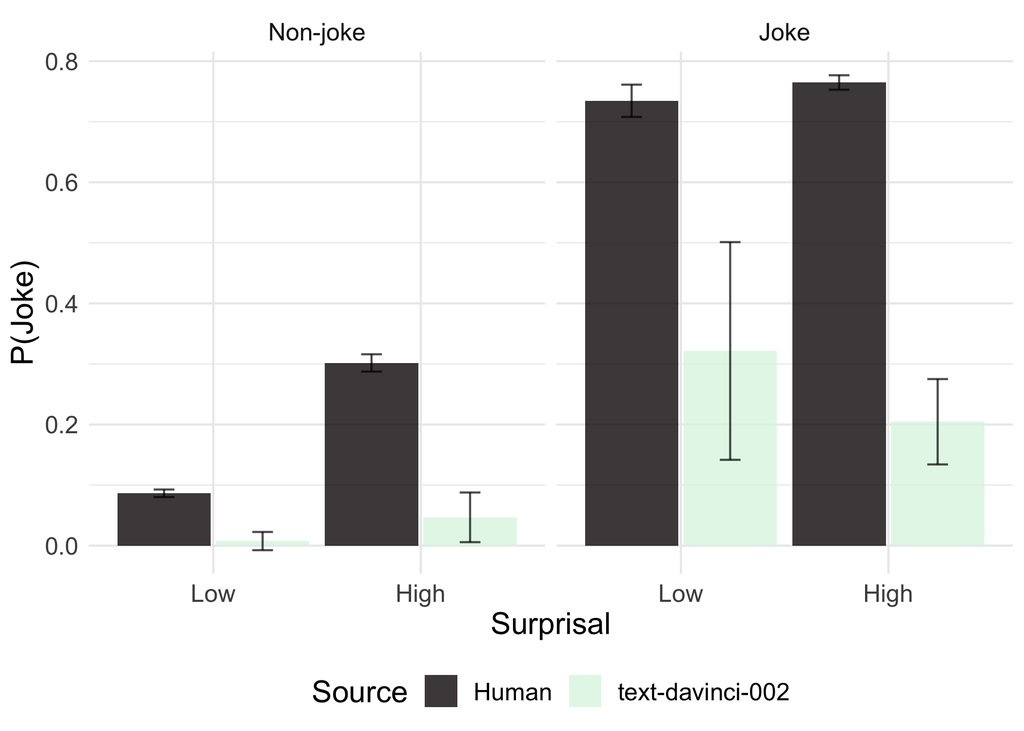

```r
df_merged_class_stacked %>%
  mutate(surprisal_binned = ifelse(ntile(surprisal, 2) == 1, "Low", "High")) %>%
  mutate(surprisal_binned = fct_relevel(surprisal_binned, "Low")) %>%
  ggplot(aes(x = factor(surprisal_binned),
             y = ResponseJoke,
             fill = Source)) +
  stat_summary (fun = function(x){mean(x)},
                geom = "col",
                position=position_dodge(width=0.95),
                size = .5, alpha = .8) +
  stat_summary (fun = function(x){mean(x)},
                geom = "errorbar",
                fun.min = function(x){mean(x) - 2*sd(x)/sqrt(length(x))},
                fun.max = function(x){mean(x) + 2*sd(x)/sqrt(length(x))},
                position=position_dodge(width=0.95),
                width = .2, alpha = .7) +
  labs(fill = "Source",
       y = "P(Joke)",
       x = "Surprisal") +
  # scale_y_continuous(limits = c(0, 1)) +
  # geom_hline(yintercept = .5, linetype = "dotted") +
    theme_minimal() +
  theme(text = element_text(size = 15),
        legend.position="bottom") +
   scale_fill_viridis(option = "mako", discrete=TRUE) +
  facet_wrap(~is_joke)
```

### Humans vs. LLMs: humor appreciation

#### `Funniness ~ Source * Surprisal`

Are LLM funniness ratings more related to sentence-final surprisal?

It *does* appear there is an interaction. The full model has the following effects:

- LLMs have higher funniness ratings on average.
- `surprisal` is positively correlated with funniness.
- The effect of `surprisal` is even more positive for LLMs.

```r
mod_interaction = lmer(data = df_merged_app_stacked,
                 ResponseFunny ~ Source * surprisal +
                   (1 | Sentence),
                 REML = FALSE)

mod_just_fe = lmer(data = df_merged_app_stacked,
                 ResponseFunny ~ Source + surprisal +
                   (1 | Sentence),
                 REML = FALSE)

summary(mod_interaction)
```

```
## Linear mixed model fit by maximum likelihood . t-tests use Satterthwaite's
##   method [lmerModLmerTest]
## Formula: ResponseFunny ~ Source * surprisal + (1 | Sentence)
##    Data: df_merged_app_stacked
##
##      AIC      BIC   logLik deviance df.resid
##  46158.0  46205.1 -23073.0  46146.0    18754
##
## Scaled residuals:
##     Min      1Q  Median      3Q     Max
## -3.2878 -0.4872 -0.1573  0.0457  4.8987
##
## Random effects:
##  Groups   Name        Variance Std.Dev.
##  Sentence (Intercept) 0.2003   0.4475
##  Residual             0.6468   0.8043
## Number of obs: 18760, groups:  Sentence, 400
##
## Fixed effects:
##                                   Estimate Std. Error        df t value
## (Intercept)                      1.253e+00  4.121e-02 3.858e+02  30.416
## Sourcetext-davinci-002           5.225e-01  7.256e-02 1.836e+04   7.201
## surprisal                        5.601e-02  5.002e-03 3.921e+02  11.198
## Sourcetext-davinci-002:surprisal 3.322e-02  8.785e-03 1.836e+04   3.782
##                                  Pr(>|t|)
## (Intercept)                       < 2e-16 ***
## Sourcetext-davinci-002           6.22e-13 ***
## surprisal                         < 2e-16 ***
## Sourcetext-davinci-002:surprisal 0.000156 ***
## ---
## Signif. codes:  0 '***' 0.001 '**' 0.01 '*' 0.05 '.' 0.1 ' ' 1
##
## Correlation of Fixed Effects:
##             (Intr) Sr--002 srprsl
## Srctxt--002 -0.033
## surprisal   -0.826  0.027
## Srctx--002:  0.027 -0.828  -0.037
```

```r
anova(mod_interaction, mod_just_fe)
```

```
## Data: df_merged_app_stacked
## Models:
## mod_just_fe: ResponseFunny ~ Source + surprisal + (1 | Sentence)
## mod_interaction: ResponseFunny ~ Source * surprisal + (1 | Sentence)
##                 npar   AIC   BIC logLik deviance  Chisq Df Pr(>Chisq)
## mod_just_fe        5 46170 46210 -23080    46160
## mod_interaction    6 46158 46205 -23073    46146 14.294  1  0.0001564 ***
## ---
## Signif. codes:  0 '***' 0.001 '**' 0.01 '*' 0.05 '.' 0.1 ' ' 1
```

One way to illustrate this is to bin surprisal and visualize funniness by binned surprisal and `Source`. Here, the effect doesn’t look all that big, but it is significant.

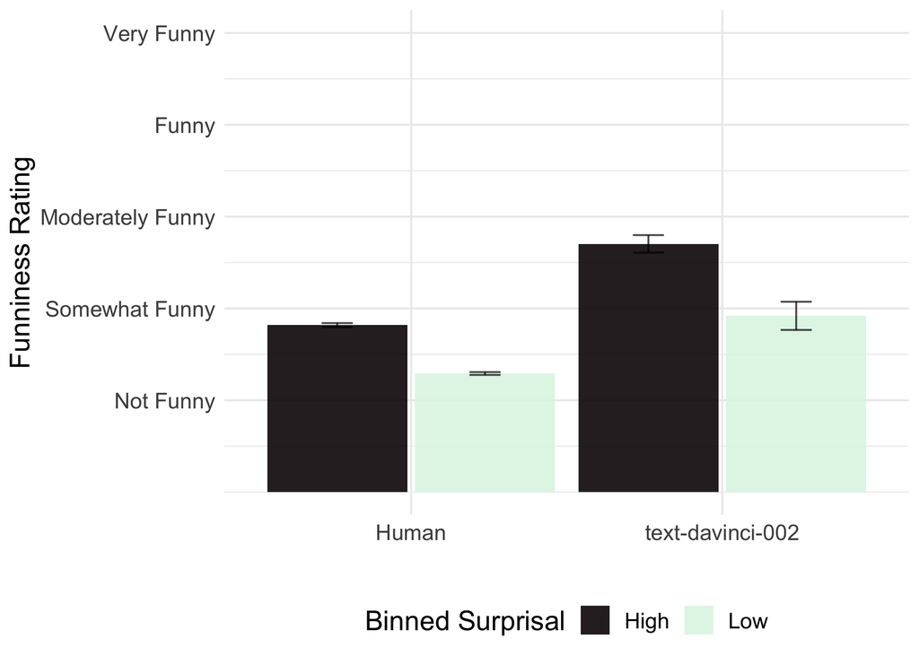

```r
df_merged_app_stacked %>%
  mutate(surprisal_binned = ifelse(ntile(surprisal, 2) == 1, "Low", "High")) %>%
  ggplot(aes(x = Source,
             y = ResponseFunny,
             fill = factor(surprisal_binned))) +
 stat_summary (fun = function(x){mean(x)},
                geom = "col",
                position=position_dodge(width=0.95),
                size = .5, alpha = .9) +
  stat_summary (fun = function(x){mean(x)},
                geom = "errorbar",
                fun.min = function(x){mean(x) - 2*sd(x)/sqrt(length(x))},
                fun.max = function(x){mean(x) + 2*sd(x)/sqrt(length(x))},
                position=position_dodge(width=0.95),
                width = .2, alpha = .7) +
  labs(x = "",
       y = "Funniness Rating",
       fill = "Binned Surprisal") +
  scale_y_continuous(breaks = c(1, 2, 3, 4, 5),
                        labels = c("Not Funny", "Somewhat Funny",
                                   "Moderately Funny", "Funny", "Very Funny"),
                     limits = c(0, 5)) +
  # scale_y_continuous(limits = c(0, 1)) +
  # geom_hline(yintercept = .5, linetype = "dotted") +
    theme_minimal() +
  theme(text = element_text(size = 15),
        legend.position="bottom") +
   scale_fill_viridis(option = "mako", discrete=TRUE)
```

We can also add `Is_Joke` to the mix. Here, it becomes a little clearer that the effect of `surprisal` is:

- Driven primarily by *non-jokes* (for both humans and LLMs).
- Larger for LLMs (again, for *non-jokes* in particular).

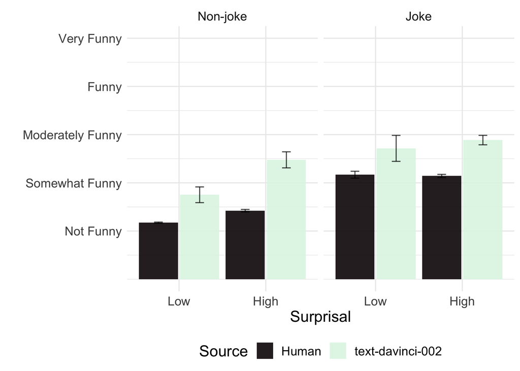

```r
df_merged_app_stacked = df_merged_app_stacked %>%
  mutate(is_joke = case_when(
    Is_Joke == 1 ~ "Joke",
    Is_Joke == 0 ~ "Non-joke"
  ))
df_merged_app_stacked$is_joke = factor(df_merged_app_stacked$is_joke, levels=c("Non-joke", "Joke"))

df_merged_app_stacked %>%
  mutate(surprisal_binned = ifelse(ntile(surprisal, 2) == 1, "Low", "High")) %>%
  mutate(surprisal_binned = fct_relevel(surprisal_binned, "Low")) %>%
  ggplot(aes(x = factor(surprisal_binned),
             y = ResponseFunny,
             fill = Source)) +
  stat_summary (fun = function(x){mean(x)},
                geom = "col",
                position=position_dodge(width=0.95),
                size = .5, alpha = .9) +
  stat_summary (fun = function(x){mean(x)},
                geom = "errorbar",
                fun.min = function(x){mean(x) - 2*sd(x)/sqrt(length(x))},
                fun.max = function(x){mean(x) + 2*sd(x)/sqrt(length(x))},
                position=position_dodge(width=0.95),
                width = .2, alpha = .7) +
  scale_y_continuous(breaks = c(1, 2, 3, 4, 5),
                        labels = c("Not Funny", "Somewhat Funny",
                                   "Moderately Funny", "Funny", "Very Funny"),
                     limits = c(0, 5)) +
  labs(fill = "Source",
       y = "",
       x = "Surprisal") +
  # scale_y_continuous(limits = c(0, 1)) +
  # geom_hline(yintercept = .5, linetype = "dotted") +
    theme_minimal() +
  theme(text = element_text(size = 15),
        legend.position="bottom") +
   scale_fill_viridis(option = "mako", discrete=TRUE) +
  facet_wrap(~is_joke)
```

## Approach 2

### Merging data

#### Merging with classification data

```r
df_class_cleaned = df_class %>%
  mutate(Sentence = sentence) %>%
  mutate(StimType = case_when(
    condition == "J" ~ "joke",
    condition == "E" ~ "expected",
    condition == "S" ~ "straight"
  )) %>%
  select(Sentence, StimType, lp_ratio, yes_lp, no_lp)

df_merged_class = df_merged_surprisal %>%
  left_join(df_class_cleaned)
nrow(df_merged_class)
```

```
## [1] 18360
```

#### Merging with appreciation data

```r
df_app_cleaned = df_app %>%
  mutate(Sentence = sentence) %>%
  mutate(StimType = case_when(
    condition == "J" ~ "joke",
    condition == "E" ~ "expected",
    condition == "S" ~ "straight"
  )) %>%
  select(Sentence, StimType, best_response, best_response_lp, entropy)

df_merged_app = df_merged_surprisal %>%
  left_join(df_app_cleaned)
nrow(df_merged_app)
```

```
## [1] 18360
```

### `Response_joke ~ Is_joke + LLM_response`

Here, we ask whether LLM responses can *explain away* the effect of recognizing things as jokes.

We find independent effects of the probability an LLM assigns to something being a joke, and the factor of whether something *is* actually being a joke.

```r
mod_full = glmer(data = df_merged_class,
                 ResponseJoke ~ Is_Joke + lp_ratio + (1 | ParticipantID) +
                   (1 | Sentence),
                 family = binomial())

mod_isjoke = glmer(data = df_merged_class,
                 ResponseJoke ~  Is_Joke + (1 | ParticipantID) +
                   (1 | Sentence),
                 family = binomial())

mod_surprisal = glmer(data = df_merged_class,
                 ResponseJoke ~  lp_ratio + (1 | ParticipantID) +
                   (1 | Sentence),
                 family = binomial())

summary(mod_full)
```

```
## Generalized linear mixed model fit by maximum likelihood (Laplace
##   Approximation) [glmerMod]
##  Family: binomial  ( logit )
## Formula: ResponseJoke ~ Is_Joke + lp_ratio + (1 | ParticipantID) + (1 |
##     Sentence)
##    Data: df_merged_class
##
##      AIC      BIC   logLik deviance df.resid
##  13079.0  13118.1  -6534.5  13069.0    18355
##
## Scaled residuals:
##      Min       1Q   Median       3Q      Max
## -10.2240  -0.3246  -0.1251   0.3162  15.7123
##
## Random effects:
##  Groups        Name        Variance Std.Dev.
##  Sentence      (Intercept) 1.571    1.253
##  ParticipantID (Intercept) 1.021    1.010
## Number of obs: 18360, groups:  Sentence, 400; ParticipantID, 153
##
## Fixed effects:
##             Estimate Std. Error z value Pr(>|z|)
## (Intercept)  -0.1550     0.1895  -0.818    0.414
## Is_Joke       2.4364     0.1721  14.157   <2e-16 ***
## lp_ratio      0.3997     0.0281  14.223   <2e-16 ***
## ---
## Signif. codes:  0 '***' 0.001 '**' 0.01 '*' 0.05 '.' 0.1 ' ' 1
##
## Correlation of Fixed Effects:
##          (Intr) Is_Jok
## Is_Joke  -0.691
## lp_ratio  0.766 -0.567
```

```r
anova(mod_full, mod_isjoke)
```

```
## Data: df_merged_class
## Models:
## mod_isjoke: ResponseJoke ~ Is_Joke + (1 | ParticipantID) + (1 | Sentence)
## mod_full: ResponseJoke ~ Is_Joke + lp_ratio + (1 | ParticipantID) + (1 | Sentence)
##            npar   AIC   BIC  logLik deviance  Chisq Df Pr(>Chisq)
## mod_isjoke    4 13246 13277 -6618.8    13238
## mod_full      5 13079 13118 -6534.5    13069 168.57  1  < 2.2e-16 ***
## ---
## Signif. codes:  0 '***' 0.001 '**' 0.01 '*' 0.05 '.' 0.1 ' ' 1
```

```r
anova(mod_full, mod_surprisal)
```

```
## Data: df_merged_class
## Models:
## mod_surprisal: ResponseJoke ~ lp_ratio + (1 | ParticipantID) + (1 | Sentence)
## mod_full: ResponseJoke ~ Is_Joke + lp_ratio + (1 | ParticipantID) + (1 | Sentence)
##               npar   AIC   BIC  logLik deviance Chisq Df Pr(>Chisq)
## mod_surprisal    4 13239 13270 -6615.3    13231
## mod_full         5 13079 13118 -6534.5    13069 161.7  1  < 2.2e-16 ***
## ---
## Signif. codes:  0 '***' 0.001 '**' 0.01 '*' 0.05 '.' 0.1 ' ' 1
```

### `Human Funniness Rating ~ LLM Funniness Rating`

Here, we ask whether LLM funniness ratings are correlated with human funniness ratings in general.

The answer is **yes**: items that LLMs rate as funnier are also rated as funnier by humans.

```r
mod_basic = lmer(data = df_merged_app,
                 ResponseFunny ~ best_response + (1 | ParticipantID) +
                   (1 | Sentence),
                 REML = FALSE)

mod_null = lmer(data = df_merged_app,
                 ResponseFunny ~ (1 | ParticipantID) +
                   (1 | Sentence),
                 REML = FALSE)

summary(mod_basic)
```

```
## Linear mixed model fit by maximum likelihood . t-tests use Satterthwaite's
##   method [lmerModLmerTest]
## Formula: ResponseFunny ~ best_response + (1 | ParticipantID) + (1 | Sentence)
##    Data: df_merged_app
##
##      AIC      BIC   logLik deviance df.resid
##  41542.3  41581.4 -20766.2  41532.3    18355
##
## Scaled residuals:
##     Min      1Q  Median      3Q     Max
## -3.8959 -0.5692 -0.1060  0.3672  5.5184
##
## Random effects:
##  Groups        Name        Variance Std.Dev.
##  Sentence      (Intercept) 0.2047   0.4524
##  ParticipantID (Intercept) 0.1384   0.3720
##  Residual                  0.5126   0.7160
## Number of obs: 18360, groups:  Sentence, 400; ParticipantID, 153
##
## Fixed effects:
##                Estimate Std. Error        df t value Pr(>|t|)
## (Intercept)     0.98980    0.07097 510.91555   13.95   <2e-16 ***
## best_response   0.26978    0.02516 390.62150   10.72   <2e-16 ***
## ---
## Signif. codes:  0 '***' 0.001 '**' 0.01 '*' 0.05 '.' 0.1 ' ' 1
##
## Correlation of Fixed Effects:
##             (Intr)
## best_respns -0.844
```

```r
anova(mod_basic, mod_null)
```

```
## Data: df_merged_app
## Models:
## mod_null: ResponseFunny ~ (1 | ParticipantID) + (1 | Sentence)
## mod_basic: ResponseFunny ~ best_response + (1 | ParticipantID) + (1 | Sentence)
##           npar   AIC   BIC logLik deviance  Chisq Df Pr(>Chisq)
## mod_null     4 41641 41672 -20816    41633
## mod_basic    5 41542 41581 -20766    41532 100.75  1  < 2.2e-16 ***
## ---
## Signif. codes:  0 '***' 0.001 '**' 0.01 '*' 0.05 '.' 0.1 ' ' 1
```

We can visualize this below:

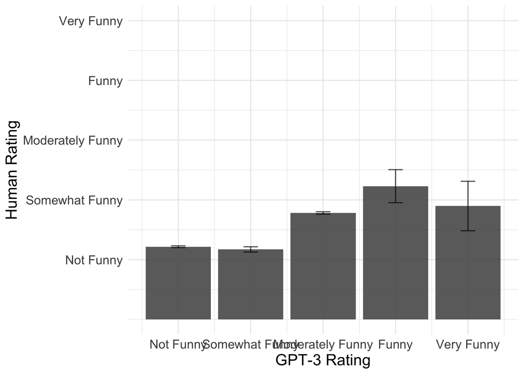

```r
df_merged_app = df_merged_app %>%
  mutate(is_joke = case_when(
    Is_Joke == 1 ~ "Joke",
    Is_Joke == 0 ~ "Non-joke"
  ))
df_merged_app$is_joke = factor(df_merged_app$is_joke, levels=c("Non-joke", "Joke"))

df_merged_app %>%
  ggplot(aes(x = best_response,
             y = ResponseFunny)) +
 stat_summary (fun = function(x){mean(x)},
                geom = "col",
                position=position_dodge(width=0.95),
                size = .5, alpha = .9) +
  stat_summary (fun = function(x){mean(x)},
                geom = "errorbar",
                fun.min = function(x){mean(x) - 2*sd(x)/sqrt(length(x))},
                fun.max = function(x){mean(x) + 2*sd(x)/sqrt(length(x))},
                position=position_dodge(width=0.95),
                width = .2, alpha = .7) +
  labs(x = "GPT-3 Rating",
       y = "Human Rating",
       fill = "Binned Surprisal") +
  scale_y_continuous(breaks = c(1, 2, 3, 4, 5),
                        labels = c("Not Funny", "Somewhat Funny",
                                   "Moderately Funny", "Funny", "Very Funny"),
                     limits = c(0, 5)) +
  scale_x_continuous(breaks = c(1, 2, 3, 4, 5),
                        labels = c("Not Funny", "Somewhat Funny",
                                   "Moderately Funny", "Funny", "Very Funny")) +
  # scale_y_continuous(limits = c(0, 1)) +
  # geom_hline(yintercept = .5, linetype = "dotted") +
    theme_minimal() +
  theme(text = element_text(size = 15),
        legend.position="bottom") +
   scale_fill_viridis(option = "mako", discrete=TRUE)
```

# Exploratory analyses

## Correlation between funniness ratings

A more direct comparison is to compare the *averaged* funniness ratings by item for humans to LLM ratings.

```r
df_merged_app_summ = df_merged_app %>%
  group_by(Sentence, Is_Joke) %>%
  summarise(mean_funniness = mean(ResponseFunny),
            llm_response = mean(best_response))
cor.test(df_merged_app_summ$mean_funniness, df_merged_app_summ$llm_response)
```

```
##
##  Pearson's product-moment correlation
##
## data:  df_merged_app_summ$mean_funniness and df_merged_app_summ$llm_response
## t = 10.599, df = 398, p-value < 2.2e-16
## alternative hypothesis: true correlation is not equal to 0
## 95 percent confidence interval:
##  0.3890378 0.5422952
## sample estimates:
##       cor
## 0.4691918
```

```r
cor.test(df_merged_app_summ$mean_funniness, df_merged_app_summ$llm_response, method = "spearman")
```

```
##
##  Spearman's rank correlation rho
##
## data:  df_merged_app_summ$mean_funniness and df_merged_app_summ$llm_response
## S = 4891965, p-value < 2.2e-16
## alternative hypothesis: true rho is not equal to 0
## sample estimates:
##       rho
## 0.5413754
```

## `Response_joke ~ Is_joke + LLM_response + surprisal`

Here, I’m curious whether LLM responses about whether something is a joke explain independent variance from sentence-final surprisal. It appears that they *do*.

```r
mod_full = glmer(data = df_merged_class,
                 ResponseJoke ~ Is_Joke + lp_ratio + surprisal +(1 | ParticipantID) +
                   (1 | Sentence),
                 family = binomial())

summary(mod_full)
```

```
## Generalized linear mixed model fit by maximum likelihood (Laplace
##   Approximation) [glmerMod]
##  Family: binomial  ( logit )
## Formula: ResponseJoke ~ Is_Joke + lp_ratio + surprisal + (1 | ParticipantID) +
##     (1 | Sentence)
##    Data: df_merged_class
##
##      AIC      BIC   logLik deviance df.resid
##  13031.3  13078.2  -6509.6  13019.3    18354
##
## Scaled residuals:
##      Min       1Q   Median       3Q      Max
## -10.4364  -0.3243  -0.1208   0.3175  16.7636
##
## Random effects:
##  Groups        Name        Variance Std.Dev.
##  Sentence      (Intercept) 1.359    1.166
##  ParticipantID (Intercept) 1.015    1.007
## Number of obs: 18360, groups:  Sentence, 400; ParticipantID, 153
##
## Fixed effects:
##             Estimate Std. Error z value Pr(>|z|)
## (Intercept) -1.05479    0.21862  -4.825 1.40e-06 ***
## Is_Joke      2.13081    0.16618  12.822  < 2e-16 ***
## lp_ratio     0.34551    0.02738  12.619  < 2e-16 ***
## surprisal    0.11699    0.01613   7.254 4.06e-13 ***
## ---
## Signif. codes:  0 '***' 0.001 '**' 0.01 '*' 0.05 '.' 0.1 ' ' 1
##
## Correlation of Fixed Effects:
##           (Intr) Is_Jok lp_rat
## Is_Joke   -0.414
## lp_ratio   0.742 -0.472
## surprisal -0.567 -0.233 -0.247
```

## `Human Funniness Rating ~ LLM Funniness Rating * Is_Joke + surprisal * Is_joke`

Here, I’m curious whether LLM funniness ratings explain independent variance from whether something is a joke and `surprisal`. It appears that they *do*, and that there is no interaction between `LLM rating * is_joke`.

That is:

- Jokes are rated as funnier by humans.
- LLM funniness ratings are positively correlated with human funniness ratings.
- There is no interaction between these factors.
- Sentence-final `surprisal` does explain additional variance.
- As already shown in the pre-registered analysis, the effect of `surprisal` is stronger for non-jokes.

```r
mod_full = lmer(data = df_merged_app,
                 ResponseFunny ~ best_response * Is_Joke + surprisal * Is_Joke+ (1 | ParticipantID) +
                   (1 | Sentence),
                 REML = FALSE)

summary(mod_full)
```

```
## Linear mixed model fit by maximum likelihood . t-tests use Satterthwaite's
##   method [lmerModLmerTest]
## Formula: ResponseFunny ~ best_response * Is_Joke + surprisal * Is_Joke +
##     (1 | ParticipantID) + (1 | Sentence)
##    Data: df_merged_app
##
##      AIC      BIC   logLik deviance df.resid
##  41220.1  41290.4 -20601.0  41202.1    18351
##
## Scaled residuals:
##     Min      1Q  Median      3Q     Max
## -3.8369 -0.5724 -0.1018  0.3682  5.5240
##
## Random effects:
##  Groups        Name        Variance Std.Dev.
##  Sentence      (Intercept) 0.08127  0.2851
##  ParticipantID (Intercept) 0.13946  0.3734
##  Residual                  0.51275  0.7161
## Number of obs: 18360, groups:  Sentence, 400; ParticipantID, 153
##
## Fixed effects:
##                         Estimate Std. Error         df t value Pr(>|t|)
## (Intercept)             1.037609   0.055480 508.280387  18.702  < 2e-16 ***
## best_response           0.066877   0.022165 379.323825   3.017 0.002723 **
## Is_Joke                 0.930038   0.136167 395.180907   6.830 3.22e-11 ***
## surprisal               0.023738   0.005208 377.971065   4.558 6.98e-06 ***
## best_response:Is_Joke   0.005973   0.047106 394.981231   0.127 0.899165
## Is_Joke:surprisal      -0.027216   0.007948 389.515609  -3.424 0.000682 ***
## ---
## Signif. codes:  0 '***' 0.001 '**' 0.01 '*' 0.05 '.' 0.1 ' ' 1
##
## Correlation of Fixed Effects:
##             (Intr) bst_rs Is_Jok srprsl b_:I_J
## best_respns -0.628
## Is_Joke     -0.288  0.257
## surprisal   -0.132 -0.413  0.054
## bst_rsp:I_J  0.296 -0.471 -0.848  0.194
## Is_Jk:srprs  0.087  0.271 -0.275 -0.655 -0.203
```

## Select items

Detection:

```r
df_subset_detection = df_merged_class %>%
  # filter(Is_Joke == FALSE) %>%
  # filter(ResponseJoke == TRUE) %>%
  group_by(Sentence, Is_Joke) %>%
  summarise(prop_joke = mean(ResponseJoke),
            mean_surprisal = mean(surprisal),
            mean_lp = mean(lp_ratio))
```

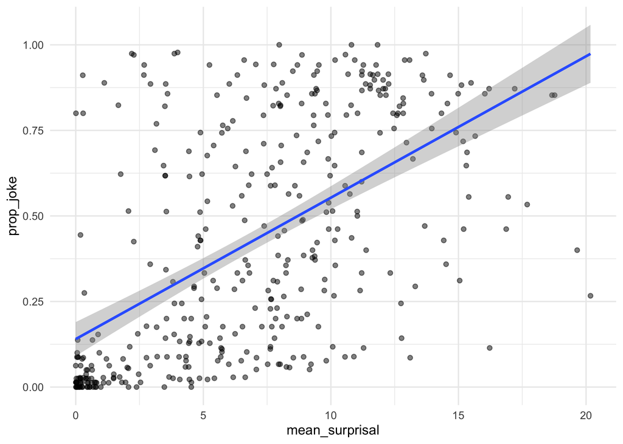

```r
df_subset_detection %>%
  ggplot(aes(x = mean_surprisal,
             y = prop_joke)) +
  geom_point(alpha = .5) +
  geom_smooth(method = "lm") +
  theme_minimal()
```

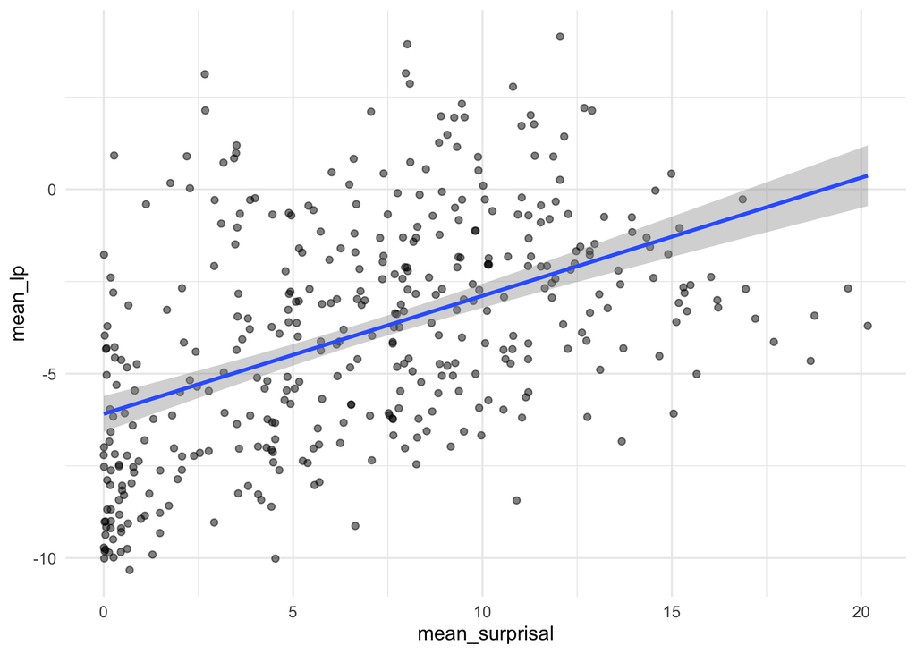

```r
df_subset_detection %>%
  ggplot(aes(x = mean_surprisal,
             y = mean_lp)) +
  geom_point(alpha = .5) +
  geom_smooth(method = "lm") +
  theme_minimal()
```

```r
cor.test(df_subset_detection$mean_surprisal, df_subset_detection$prop_joke)
```

```
##
##  Pearson's product-moment correlation
##
## data:  df_subset_detection$mean_surprisal and df_subset_detection$prop_joke
## t = 13.531, df = 398, p-value < 2.2e-16
## alternative hypothesis: true correlation is not equal to 0
## 95 percent confidence interval:
##  0.4902476 0.6249715
## sample estimates:
##       cor
## 0.5613171
```

```r
cor.test(df_subset_detection$mean_surprisal, df_subset_detection$mean_lp)
```

```
##
##  Pearson's product-moment correlation
##
## data:  df_subset_detection$mean_surprisal and df_subset_detection$mean_lp
## t = 10.774, df = 398, p-value < 2.2e-16
## alternative hypothesis: true correlation is not equal to 0
## 95 percent confidence interval:
##  0.3955653 0.5477185
## sample estimates:
##       cor
## 0.4751865
```

Appreciation:

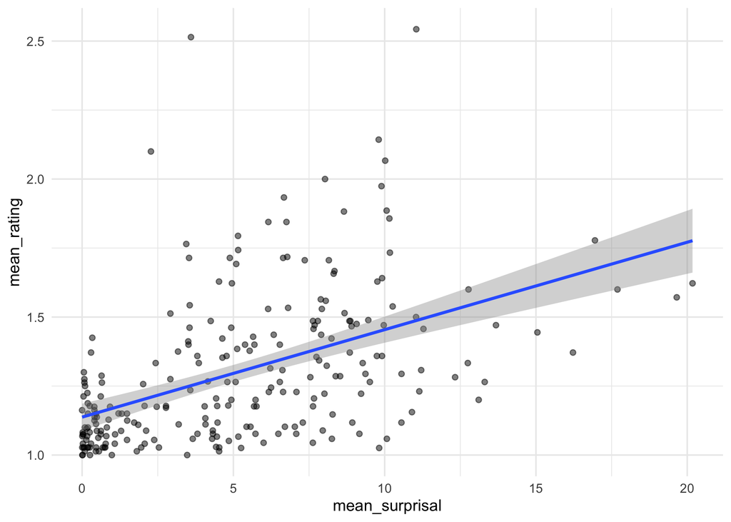

```r
df_subset_appreciation = df_merged_app %>%
  filter(Is_Joke == FALSE) %>%
  # filter(ResponseJoke == TRUE) %>%
  group_by(Sentence) %>%
  summarise(mean_rating = mean(ResponseFunny),
            mean_surprisal = mean(surprisal),
            mean_rating_llm = mean(best_response))

df_subset_appreciation %>%
  ggplot(aes(x = mean_surprisal,
             y = mean_rating)) +
  geom_point(alpha = .5) +
  geom_smooth(method = "lm") +
  theme_minimal()
```

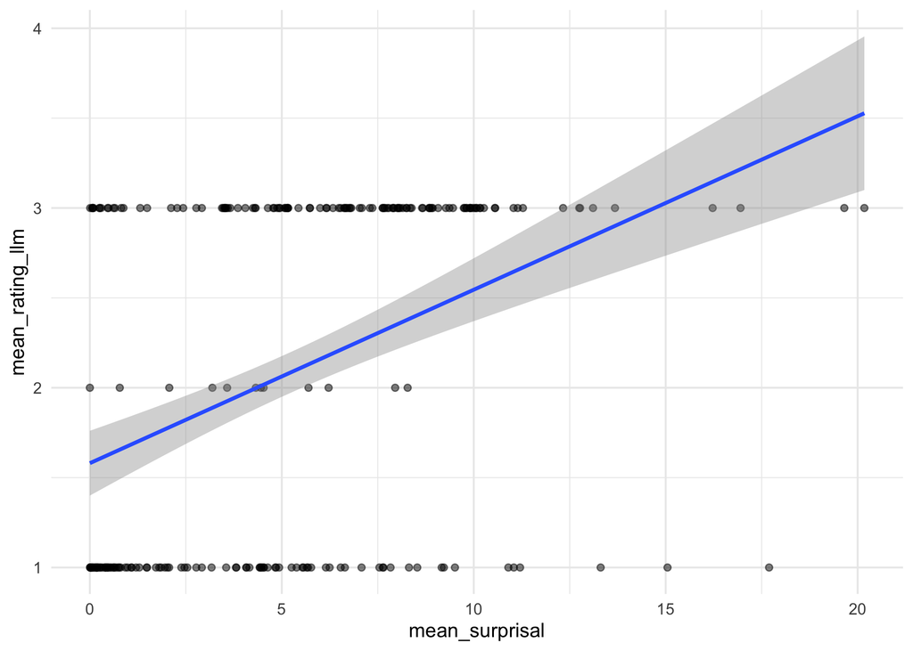

```r
df_subset_appreciation %>%
  ggplot(aes(x = mean_surprisal,
             y = mean_rating_llm)) +
  geom_point(alpha = .5) +
  geom_smooth(method = "lm") +
  theme_minimal()
```

```r
cor.test(df_subset_appreciation$mean_surprisal, df_subset_appreciation$mean_rating)
```

```
##
##  Pearson's product-moment correlation
##
## data:  df_subset_appreciation$mean_surprisal and df_subset_appreciation$mean_rating
## t = 8.4207, df = 238, p-value = 3.546e-15
## alternative hypothesis: true correlation is not equal to 0
## 95 percent confidence interval:
##  0.3752454 0.5710914
## sample estimates:
##       cor
## 0.4791093
```

```r
cor.test(df_subset_appreciation$mean_surprisal, df_subset_appreciation$mean_rating_llm)
```

```
##
##  Pearson's product-moment correlation
##
## data:  df_subset_appreciation$mean_surprisal and df_subset_appreciation$mean_rating_llm
## t = 6.9446, df = 238, p-value = 3.593e-11
## alternative hypothesis: true correlation is not equal to 0
## 95 percent confidence interval:
##  0.2994118 0.5105697
## sample estimates:
##       cor
## 0.4104786
```